# Practical Machine Learning - Course Project

Cherie Bardsley

August 20, 2018

# Prediction Assignment

## Background

Using devices such as *Jawbone Up, Nike, FuelBand,* and *Fitbit* it is now possible to collect a large amount of data about personal activity relatively inexpensively. These type of devices are part of the quantified self movement - a group of enthusiasts who take measurements about themselves regularly to improve their health, to find patterns in their behavior, or because they are tech geeks. One thing that people regularly do is quantify how *much* of a particular activity they do, but they rarely quantify *how well they do it.*

In this project, the goal was to use data from accelerometers on the belt, forearm, arm, and dumbell of 6 participants. They were asked to perform barbell lifts correctly and incorrectly in 5 different ways. More information is available from this website: http://groupware.les.inf.puc-rio.br/har (see the section on the Weight Lifting Exercise Dataset).

## Data

The training data for this project are available here: https://d396qusza40orc.cloudfront.net/predmachlearn/pml-training.csv

The test data are available here: https://d396qusza40orc.cloudfront.net/predmachlearn/pml-testing.csv

## Project Rubric

The goal of this project is to predict the manner in which the participants did the exercise. This is the ‘classe’ variable in the training set. We can use any of the other variables to predict with.

This report will describe how our model was built, how we used cross validation, what we think the expected out of sample error is, and why we made the choices we did. We will use our prediction model to predict 20 different test cases.

The submission should consist of a link to a Gihub repo with the R markdown and compiled HTML file describing the analysis. The text of the writeup should be constrained to < 2000 words and the number of figures should be less than 5. To make it easier for the graders, we will submit a repo with a gh-pages branch so the HTML page can be viewed online.

## Loading the R Packages and Preparing the Data

### Load the Required R Packages

```r
library(caret)
library(rattle)
```

```r
library(rpart)
library(rpart.plot)
library(randomForest)
```

### Get the Data

```r
training <- read.csv("pml-training.csv")
testing <- read.csv("pml-testing.csv")
```

### Explore the Data

```r
dim(training); dim(testing)
```

```
## [1] 19622   160
```

```
## [1]  20 160
```

The raw training data set has 19622 observations and 160 variables. The raw testing data set has 20 observations and 160 variables.

The outcome variable ‘classe’ is the last column in the raw training data set.

### Clean the Data

In exploring the data, the first thing we noticed is that many of the variables have extremely low variances. There is little information in these variables so we will use the caret package nearZeroVar() function to remove them from both the training and testing data sets.

```r
nzv <- nearZeroVar(training, saveMetrics = TRUE)
training <- training[, nzv$nzv == FALSE]
nzv <- nearZeroVar(testing, saveMetrics = TRUE)
testing <- testing[, nzv$nzv == FALSE]
dim(training); dim(testing)
```

```
## [1] 19622   100
```

```
## [1] 20 59
```

After running nearZeroVar() our modified training data set now has 19622 observations and 100 variables. Our modified testing data set now has 20 observations and 59 variables.

Next, we noticed that some of the columns in the training set have NA or missing values. We will delete these columns as they will not contribute to our prediction.

```r
trainingClean1 <- training[, colSums(is.na(training)) == 0]
testingClean1 <- testing[, colSums(is.na(testing)) == 0]
```

We also noticed the first seven columns appear to contain data about the participants, timestamps, and windows. We removed these columns as they will not contribute to our prediction for the outcome ‘classe’.

```r
trainingClean2 <- trainingClean1[, -c(1:7)]
testingClean2 <- testingClean1[, -c(1:7)]
```

Our last step will be to rename our cleaned training and testing data sets.

```r
trainingCleaned <- trainingClean2
testingCleaned <- testingClean2
testing <- testingCleaned
dim(trainingCleaned); dim(testing)
```

```
## [1] 19622    52
```

```
## [1] 20 52
```

Our cleaned training (‘trainingCleaned’) and testing (‘testing’) data sets now have 52 columns. The ‘trainingCleaned’ set has 19622 observations and the last column in the data set is our outcome variable ‘classe’. The ‘testing’ set has 20 observations and the last column in the data set is the ‘problem_id’ variable.

### Data Splitting

To get the out of sample errors, we need to split the ‘trainingCleaned’ data set into a ‘training’ set, which we and a ‘validation’ set.

```r
set.seed(33533)
inTrain <- createDataPartition(trainingCleaned$classe, p = 0.7, list = FALSE)
training <- trainingCleaned[inTrain,]
validation <- trainingCleaned[-inTrain,]
```

## Machine Learning Model

We will use three different models to predict the manner in which the participants did the exercise, Classification Trees, Boosting and Random Forests, and use the most accurate model for our prediction on the testing set.

### Cross Validation Method

```r
# Set the number of folds to 5
control <- trainControl(method = "cv", number = 5)
```

### Classification Trees

```r
# Fit the model
modCT <- train(classe ~ ., method = "rpart", data = training, trControl = control)
print(modCT, digits = 4)
```

```
## CART
##
## 13737 samples
##    51 predictor
##     5 classes: 'A', 'B', 'C', 'D', 'E'
##
## No pre-processing
## Resampling: Cross-Validated (5 fold)
## Summary of sample sizes: 10991, 10988, 10989, 10990, 10990
## Resampling results across tuning parameters:
##
##   cp       Accuracy  Kappa
##   0.03011  0.5190    0.3813
##   0.03387  0.5000    0.3558
##   0.06340  0.3535    0.1156
##
## Accuracy was used to select the optimal model using  the largest value.
## The final value used for the model was cp = 0.03011.
```

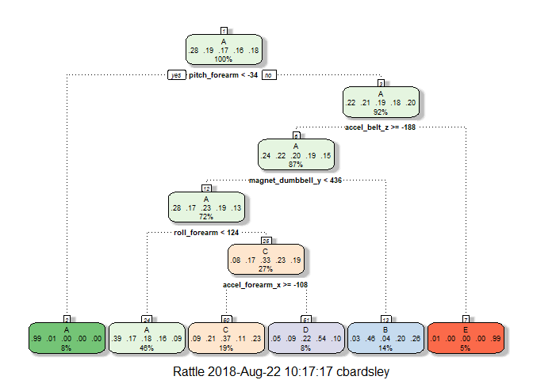

```r
# Plot the classification tree
fancyRpartPlot(modCT$finalModel)
```

```r
# Predict on the validation set
predCT <- predict(modCT, validation)
# Display the prediction results using the confusionMatrix function
confCT <- confusionMatrix(validation$classe, predCT)
confCT
```

```
## Confusion Matrix and Statistics
##
##           Reference
## Prediction    A    B    C    D    E
##          A 1516   39   90   28    1
##          B  465  385  251   38    0
##          C  472   32  413  109    0
##          D  438  176  123  227    0
##          E  263  201  254   52  312
##
## Overall Statistics
##
##                Accuracy : 0.4848
##                  95% CI : (0.4719, 0.4977)
##     No Information Rate : 0.5359
##     P-Value [Acc > NIR] : 1
##
##                   Kappa : 0.3259
##  Mcnemar's Test P-Value : <2e-16
##
## Statistics by Class:
##
##                      Class: A Class: B Class: C Class: D Class: E
## Sensitivity            0.4807  0.46218  0.36516  0.50000  0.99681
## Specificity            0.9421  0.85075  0.87106  0.86430  0.86181
## Pos Pred Value         0.9056  0.33802  0.40253  0.23548  0.28835
## Neg Pred Value         0.6110  0.90560  0.85223  0.95387  0.99979
## Prevalence             0.5359  0.14155  0.19218  0.07715  0.05319
## Detection Rate         0.2576  0.06542  0.07018  0.03857  0.05302
## Detection Prevalence   0.2845  0.19354  0.17434  0.16381  0.18386
## Balanced Accuracy      0.7114  0.65647  0.61811  0.68215  0.92931
```

The accuracy of this first model is very low at 0.4848 and the out of sample error rate is 0.5152. Therefore, we conclude the Classification Trees model does not predict the ‘classe’ outcome very well.

### Gradient Boosting

```r
# Fit the model
modGBM <- train(classe ~ ., method = "gbm", data = training, verbose = FALSE)
print(modGBM)
```

```
## Stochastic Gradient Boosting
##
## 13737 samples
##    51 predictor
##     5 classes: 'A', 'B', 'C', 'D', 'E'
##
## No pre-processing
## Resampling: Bootstrapped (25 reps)
## Summary of sample sizes: 13737, 13737, 13737, 13737, 13737, 13737, ...
## Resampling results across tuning parameters:
##
##   interaction.depth  n.trees  Accuracy   Kappa
##   1                   50      0.7369449  0.6663474
##   1                  100      0.8086647  0.7577003
##   1                  150      0.8440833  0.8025217
##   2                   50      0.8487731  0.8083270
##   2                  100      0.9022060  0.8761492
##   2                  150      0.9261039  0.9064408
##   3                   50      0.8891864  0.8596101
##   3                  100      0.9360045  0.9189727
##   3                  150      0.9546518  0.9425981
##
## Tuning parameter 'shrinkage' was held constant at a value of 0.1
##
## Tuning parameter 'n.minobsinnode' was held constant at a value of 10
## Accuracy was used to select the optimal model using  the largest value.
## The final values used for the model were n.trees = 150,
##  interaction.depth = 3, shrinkage = 0.1 and n.minobsinnode = 10.
```

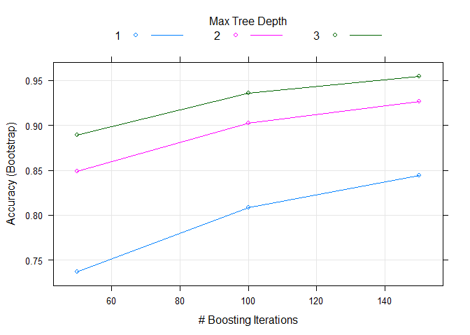

```r
# Plot the Boosting Model
plot(modGBM)
```

```r
# Predict on the validation set
predGBM <- predict(modGBM, validation)
# Display the prediction results using the confusionMatrix function
confGBM <- confusionMatrix(validation$classe, predGBM)
confGBM
```

```
## Confusion Matrix and Statistics
##
##           Reference
## Prediction    A    B    C    D    E
##          A 1637   23    9    2    3
##          B   34 1076   25    0    4
##          C    0   28  983   13    2
##          D    1    4   29  917   13
##          E    1    9   12   10 1050
##
## Overall Statistics
##
##                Accuracy : 0.9623
##                  95% CI : (0.9571, 0.967)
##     No Information Rate : 0.2843
##     P-Value [Acc > NIR] : < 2.2e-16
##
##                   Kappa : 0.9523
##  Mcnemar's Test P-Value : 0.0003739
##
## Statistics by Class:
##
##                      Class: A Class: B Class: C Class: D Class: E
## Sensitivity            0.9785   0.9439   0.9291   0.9735   0.9795
## Specificity            0.9912   0.9867   0.9911   0.9905   0.9934
## Pos Pred Value         0.9779   0.9447   0.9581   0.9512   0.9704
## Neg Pred Value         0.9915   0.9865   0.9846   0.9949   0.9954
## Prevalence             0.2843   0.1937   0.1798   0.1601   0.1822
## Detection Rate         0.2782   0.1828   0.1670   0.1558   0.1784
## Detection Prevalence   0.2845   0.1935   0.1743   0.1638   0.1839
## Balanced Accuracy      0.9848   0.9653   0.9601   0.9820   0.9864
```

### Random Forests

We will now move to the random forest method to see if it performs better than the other two models.

```r
# Fit the model
modRF <- train(classe ~ ., method = "rf", data = training, trControl = control)
print(modRF, digits = 4)
```

```
## Random Forest
##
## 13737 samples
##    51 predictor
##     5 classes: 'A', 'B', 'C', 'D', 'E'
##
## No pre-processing
## Resampling: Cross-Validated (5 fold)
## Summary of sample sizes: 10991, 10990, 10989, 10990, 10988
## Resampling results across tuning parameters:
##
##   mtry  Accuracy  Kappa
##    2    0.9888    0.9858
##   26    0.9915    0.9892
##   51    0.9881    0.9849
##
## Accuracy was used to select the optimal model using  the largest value.
## The final value used for the model was mtry = 26.
```

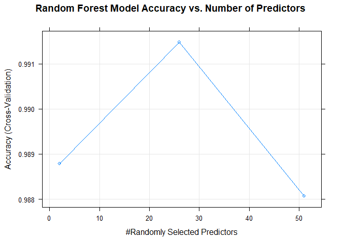

```r
# Plot the accuracy of the model vs. the number of predictors
plot(modRF, main = "Random Forest Model Accuracy vs. Number of Predictors")
```

```r
# Predict on the validation set
predRF <- predict(modRF, validation)
# Display the prediction results using the confusionMatrix function
confCT <- confusionMatrix(validation$classe, predRF)
confCT
```

```
## Confusion Matrix and Statistics
##
##           Reference
## Prediction    A    B    C    D    E
##          A 1669    4    0    0    1
##          B    2 1133    4    0    0
##          C    0    2 1021    3    0
##          D    0    1    7  953    3
##          E    0    0    1    2 1079
##
## Overall Statistics
##
##                Accuracy : 0.9949
##                  95% CI : (0.9927, 0.9966)
##     No Information Rate : 0.2839
##     P-Value [Acc > NIR] : < 2.2e-16
##
##                   Kappa : 0.9936
##  Mcnemar's Test P-Value : NA
##
## Statistics by Class:
##
##                      Class: A Class: B Class: C Class: D Class: E
## Sensitivity            0.9988   0.9939   0.9884   0.9948   0.9963
## Specificity            0.9988   0.9987   0.9990   0.9978   0.9994
## Pos Pred Value         0.9970   0.9947   0.9951   0.9886   0.9972
## Neg Pred Value         0.9995   0.9985   0.9975   0.9990   0.9992
## Prevalence             0.2839   0.1937   0.1755   0.1628   0.1840
## Detection Rate         0.2836   0.1925   0.1735   0.1619   0.1833
## Detection Prevalence   0.2845   0.1935   0.1743   0.1638   0.1839
## Balanced Accuracy      0.9988   0.9963   0.9937   0.9963   0.9978
```

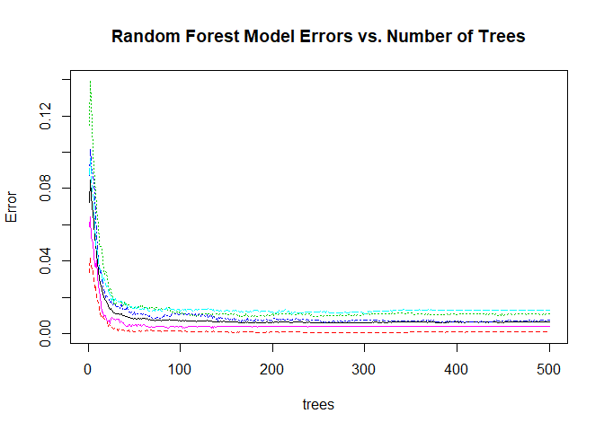

```r
# Plot the errors vs. the number of trees for the final model
plot(modRF$finalModel, main = "Random Forest Model Errors vs. Number of Trees")
```

The Random Forest model performed better than both the Classification Trees and Gradient Boosting models with 0.9949 accuracy and an out of sample error rate of 0.0051 using cross validation with 5 folds.

## Prediction on the Testing Set Using the Best (Most Accurate) Model

As the Random Forest model is the most accurate of the three models, we will use it to predict the values of ‘classe’ on the testing data set.

```r
predTest <- predict(modRF, newdata = testing)
predTest
```

```
##  [1] B A B A A E D B A A B C B A E E A B B B
## Levels: A B C D E
```